# 二手车估价模型

```
## stat_bin: binwidth defaulted to range/30. Use 'binwidth = x' to adjust this.
```

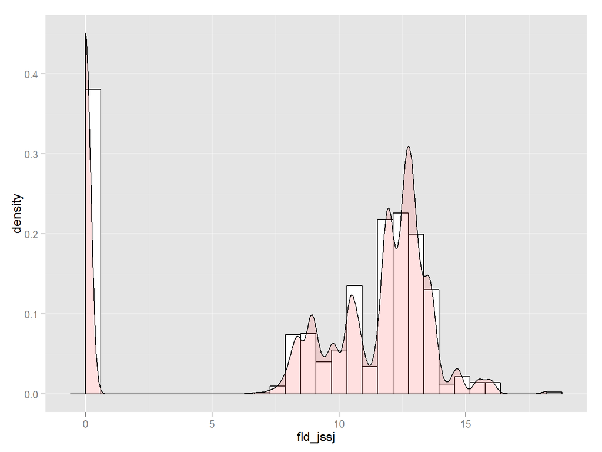

fld_yhzh综合油耗(l/100km)

```
## car_data_2009_2014$fld_yhzh
##       n missing  unique    Info    Mean     .05     .10     .25     .50
##  713513       0      69       1    7.79     5.8     6.2     7.0     7.8
##     .75     .90     .95
##     8.5     9.4     9.5
##
## lowest :  0.00  4.60  5.20  5.30  5.40
## highest: 10.80 11.08 11.20 11.30 13.60
```

```
## stat_bin: binwidth defaulted to range/30. Use 'binwidth = x' to adjust this.
```

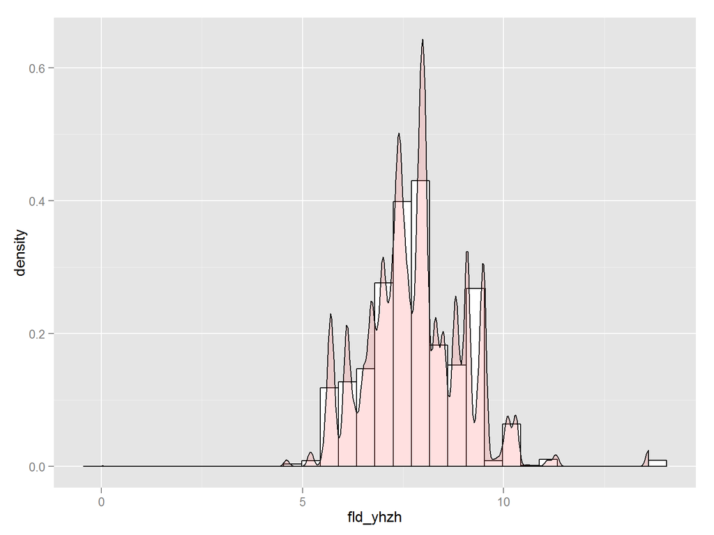

fld_gtcl缸体材料，发动机制作材料，分为2类：1：铝合金；2：铸铁

```
##
##     1     2
## 52.65 47.35
```

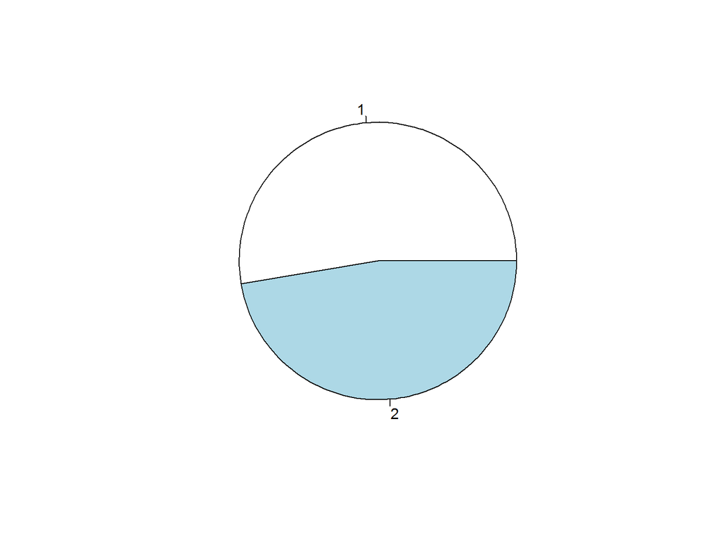

fld_qgsl气缸数

```
## car_data_2009_2014$fld_qgsl
##       n missing  unique    Info    Mean
##  713513       0       3     0.3   4.223
##
## 0 (179, 0%), 4 (633526, 89%), 6 (79808, 11%)
```

```
##
##     0     4     6
##  0.03 88.79 11.19
```

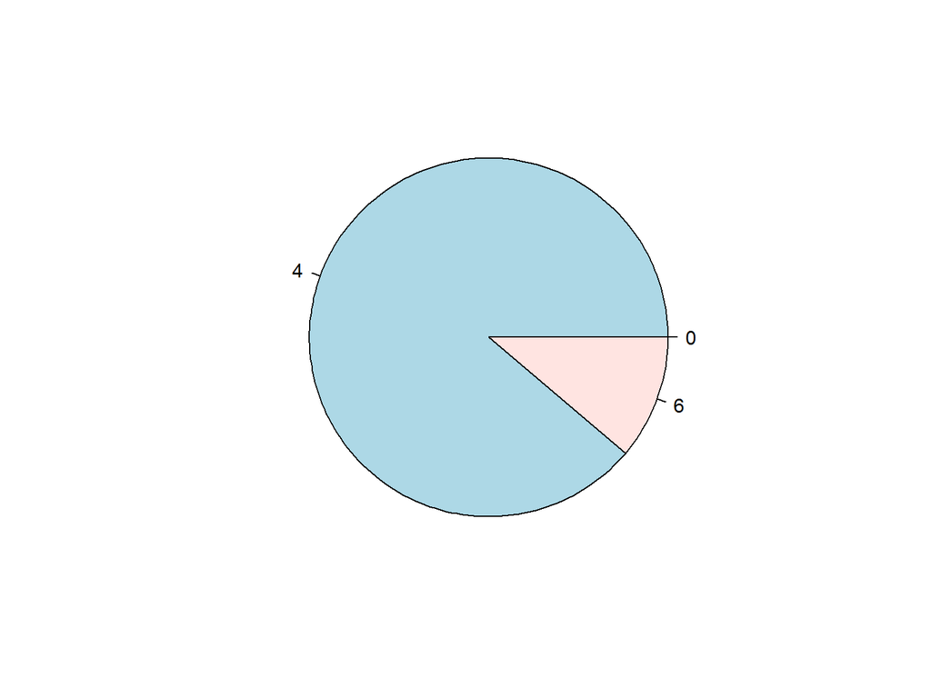

衍生变量产生和数据清洗,需要导出下面衍生变量  
，残值率(res_ratio)=fld_appraise/fld_price

车龄(按照月计算)age=车辆登记时间-车辆上牌时间

生成一个车龄区间变量car_age10(0,1],(1,2],…(10,11]

每月万公里speed=fld_mileage/age

季节quarter为抽取成交时间为那个季度

数据清洗规则

残值率res_ratio<=0.98 & res_ratio>=0.1  
车龄 age<=15*12 & age>=2  
把属于宁波地区的成交数据去掉 fld_szd!=“宁波”  
把 fld_status !=“撤销” 属于撤销的数据删除  
把每月里程(每月万公里)限制在这个区间speed <1.5 & speed >0.005  
出厂日期大于2004年fld_ccsj>=2004，以前数据有问题

```
## stat_bin: binwidth defaulted to range/30. Use 'binwidth = x' to adjust this.
## stat_bin: binwidth defaulted to range/30. Use 'binwidth = x' to adjust this.
## stat_bin: binwidth defaulted to range/30. Use 'binwidth = x' to adjust this.
```

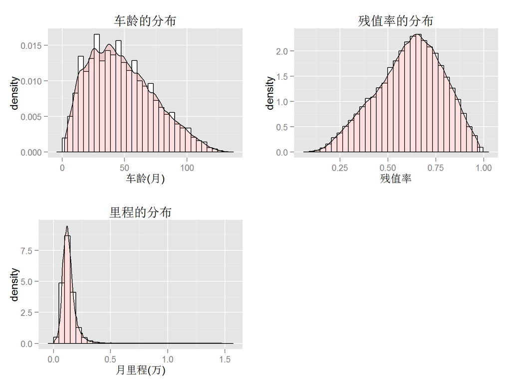

清洗后数据fld_szdmain省份的饼图

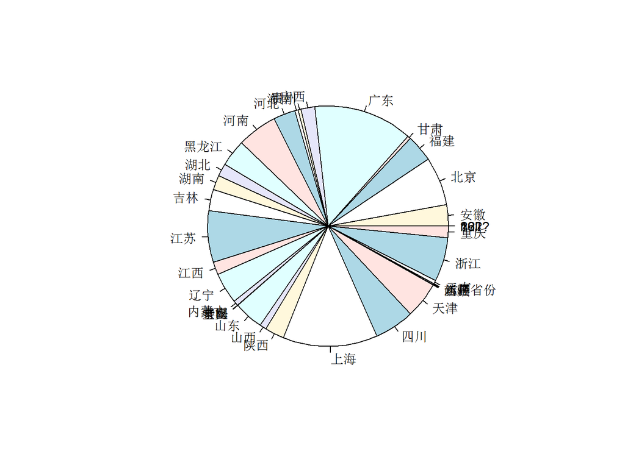

分类变量的合并  
合并原则:超过十二个值的分类变量一般都要进行合并  
合并后的分类变量一般频数相差不大，合并的分类值残值率相近 对以下分类变量进行合并：

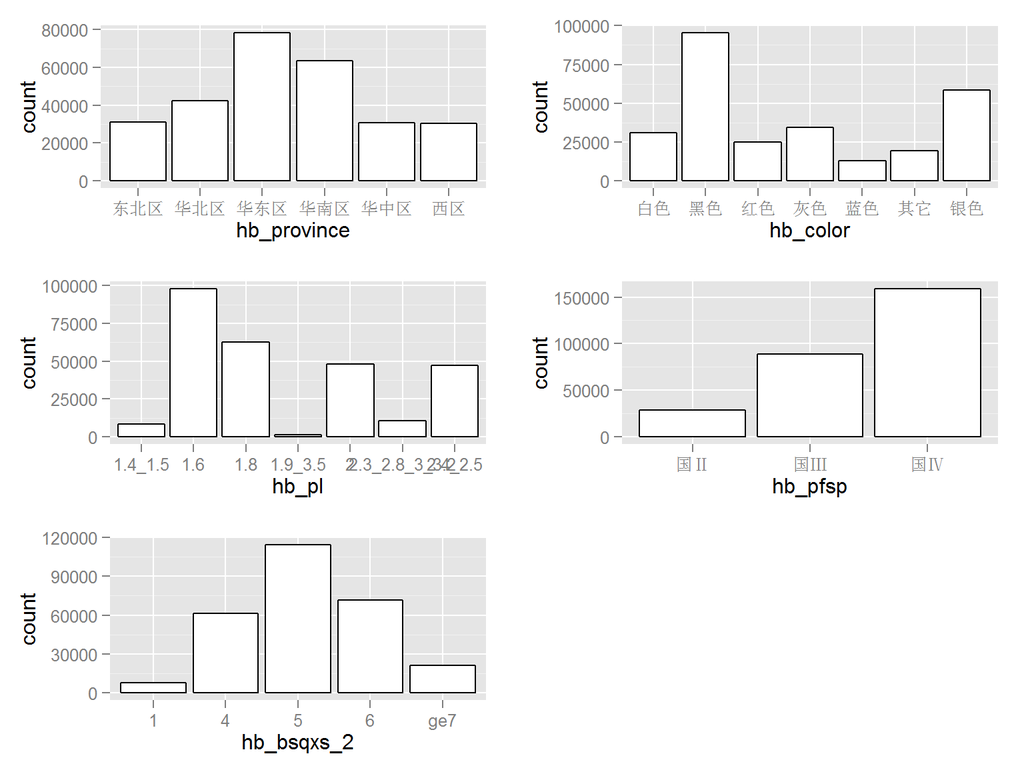

合并后品牌频数图

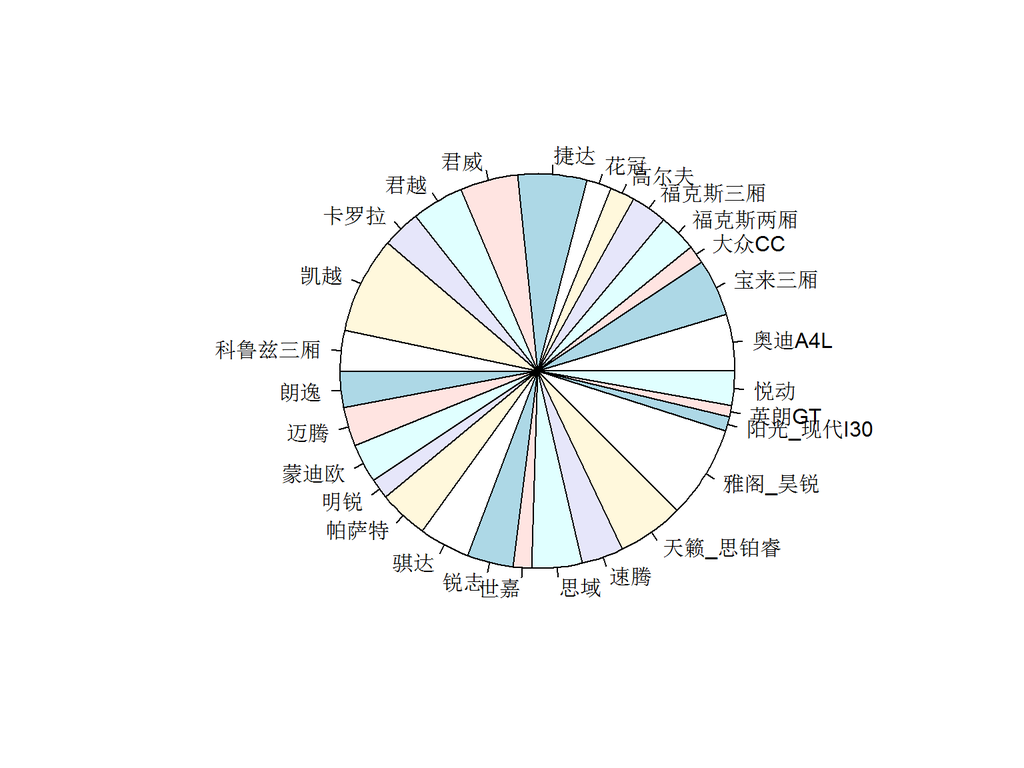

```
##        fld_ycyt fld_trim_status        fld_qdfs        fld_qgsl
##            0.00            0.28           12.42           13.32
##        fld_gtcl       fld_level        fld_jqfs       fld_ctlx2
##           16.25           16.26           17.02           17.27
##      fld_rllxbh         quarter         fld_bxq        fld_pfsp
##           19.20           19.63           21.87           25.30
##       fld_bsqxs          fld_zj          fld_pl        fld_jssj
##           25.38           28.13           31.95           33.29
##        fld_ccsj        fld_zbzl        hb_color        fld_yhzh
##           33.44           34.94           40.19           42.02
##           speed        hb_model     hb_province             age
##           43.04           43.07           54.48           61.06
```

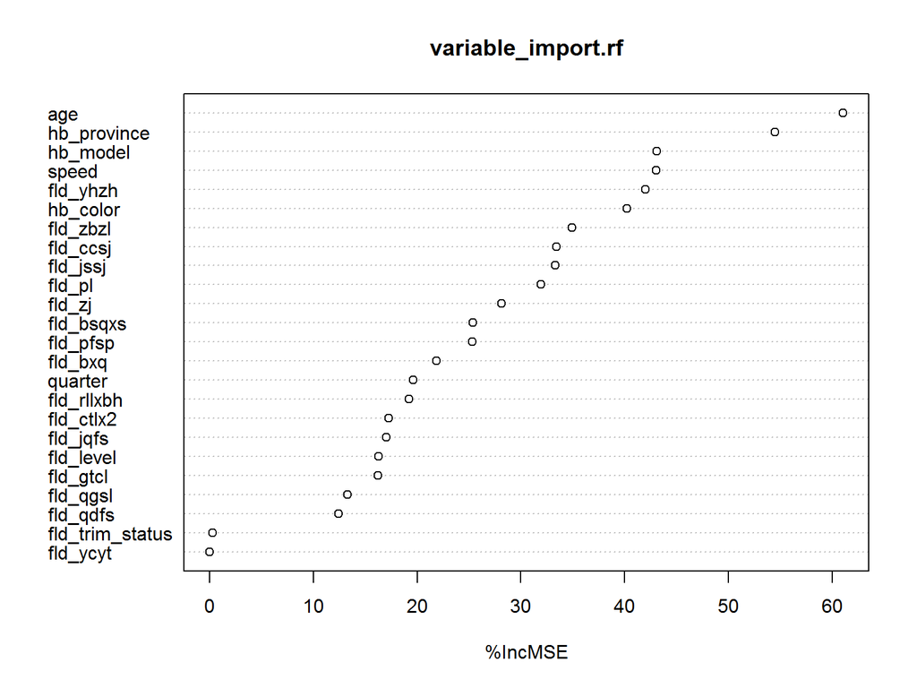

变量的选择，对二手车估价模型而言目标变量是残值率，其它变量为预测变量，那么我们要看在这些预测变量里面 那些变量具有强预测性，也就是对预测变量进行预测重要性排序。 根据变量的商业意义，我们第一轮筛选预测变量用了以下变量

```
##  [1] "fld_level"       "fld_trim_status" "fld_ccsj"
##  [4] "fld_pl"          "fld_qdfs"        "fld_jqfs"
##  [7] "fld_bsqxs"       "fld_pfsp"        "fld_bxq"
## [10] "fld_ycyt"        "fld_ctlx2"       "fld_rllxbh"
## [13] "fld_zj"          "fld_zbzl"        "fld_jssj"
## [16] "fld_yhzh"        "fld_gtcl"        "fld_qgsl"
```

```
##     quarter    fld_gtcl   fld_ctlx2     fld_bxq  hb_bsqxs_2     hb_pfsp
##       21.45       22.22       26.27       29.46       31.49       42.86
##       speed    hb_color       hb_pl hb_province    hb_model         age
##       51.29       52.35       52.90       74.12       80.86      163.99
```

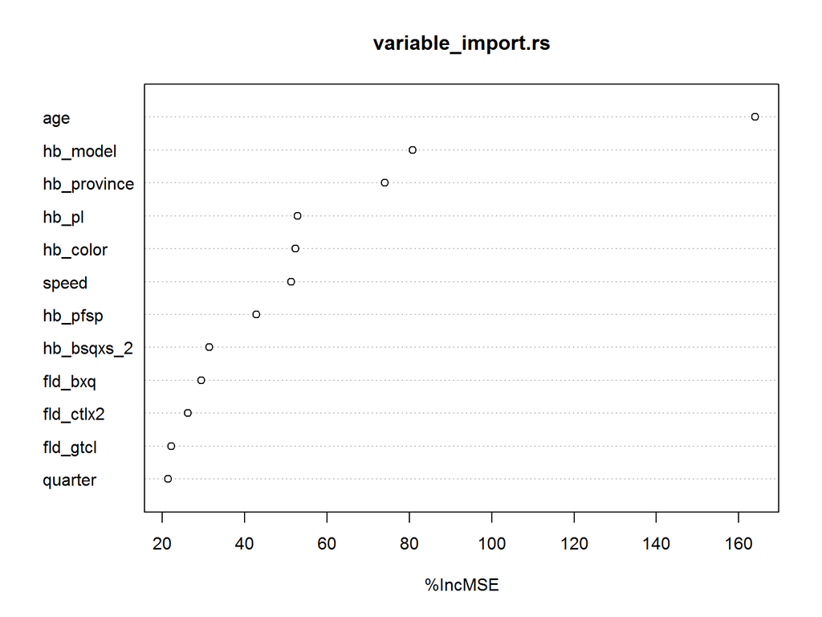

第二轮筛选弃掉一些重要性低的变量和一些相关性高的变量（比如轴距，重量，油耗等）

```
##  [1] "hb_province" "hb_model"    "hb_pl"       "fld_gtcl"    "fld_ctlx2"
##  [6] "fld_bxq"     "hb_color"    "age"         "hb_pfsp"     "speed"
## [11] "quarter"     "hb_bsqxs_2"  "fld_jqfs"    "price"
```

查看一些第二次变量重要性排序后，得知对残值率影响最大的因素分别为车龄，车型， 地区，排量，颜色，每月里程，排放标准，变速箱方式，保修期，车体类型，缸体材料，季度。

对fld_hits变量的分析,分析点击次数和品牌的频数关系

```
##
##                (0,2] (2,59] (59,149] (149,309] (309,521] (521,1e+04]
##   奥迪A4L        383   4263     1908      1355       611         693
##   宝来三厢       189   3549     3337      1948       618         616
##   大众CC         175   1079      686       412       175         202
##   福克斯两厢     161   2002     2257      1376       414         437
##   福克斯三厢     127   1864     2360      1215       392         384
##   高尔夫         156   1334      969       936       355         458
##   花冠            86   1224     1508       781       211         235
##   捷达           207   3155     4524      2761       852         813
##   君威           180   3302     3770      1993       663         675
##   君越           214   2910     2986      1748       590         549
##   卡罗拉         170   2323     1960      1171       392         340
##   凯越           225   5434     7316      3358       943         822
##   科鲁兹三厢     221   2531     1783      1361       515         500
##   朗逸           180   2514     1496       980       324         319
##   迈腾           180   2143     1691      1192       426         482
##   蒙迪欧         173   1977     2256      1479       527         527
##   明锐            83   1293      934       592       213         180
##   帕萨特         154   2429     2903      1619       610         698
##   骐达           159   2515     3580      1952       532         514
##   锐志           290   2248     2408      1583       574         635
##   世嘉            64    996      862       611       210         275
##   思域           183   2738     2692      1730       545         562
##   速腾           197   2376     1825      1542       546         496
##   天籁_思铂睿    348   3544     3674      2251       807         672
##   雅阁_昊锐      349   4901     5768      3216      1088        1155
##   阳光_现代I30    56    706      830       530       149         136
##   英朗GT          66    724      392       276       128         100
##   悦动           100   2063     1914      1168       355         305
##
##                (1e+04,2.35e+04]
##   奥迪A4L                     0
##   宝来三厢                    3
##   大众CC                      0
##   福克斯两厢                  0
##   福克斯三厢                  0
##   高尔夫                      0
##   花冠                        0
##   捷达                        0
##   君威                        0
##   君越                        0
##   卡罗拉                      1
##   凯越                        0
##   科鲁兹三厢                  1
##   朗逸                        0
##   迈腾                        0
##   蒙迪欧                      1
##   明锐                        0
##   帕萨特                      1
##   骐达                        0
##   锐志                        1
##   世嘉                        1
##   思域                        1
##   速腾                        0
##   天籁_思铂睿                 0
##   雅阁_昊锐                   1
##   阳光_现代I30                0
##   英朗GT                      0
##   悦动                        1
```

```
## [1] 0.07463775
```

```
## [1] 0.07746505
```

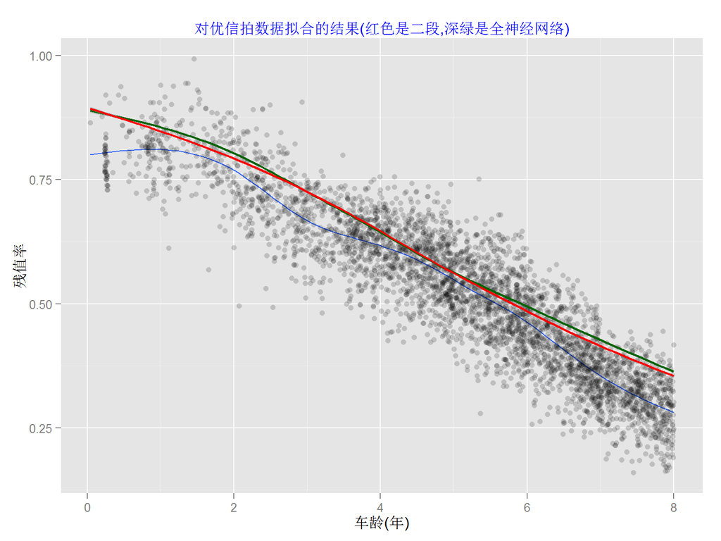

这里使用了神经网络包nnet，建立模型，模型的topology如下图，考察模型指标的MRSE如下

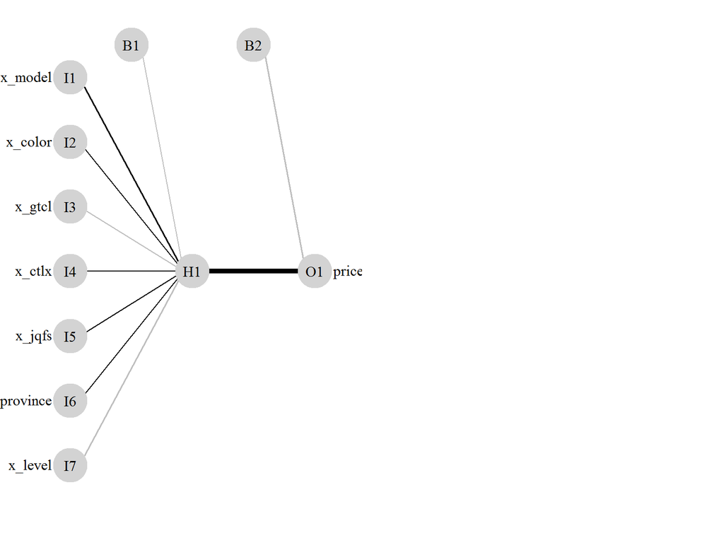

衡量神经网络效果的指标 RMSE(Root mean squared error) 均方根误差 衡量拟合残值率和实际残值率的差别,统计参数，也叫回归系统的拟合标准差. $RMSE=\sqrt{MSE}=\sqrt{\frac{1}{n}SSE}=\sqrt{\frac{1}{n}\sum_i{y_i − \hat{y_i}}^2}$ 一般来说MRSE越小，说明模型给出的残值率和实际残值率越接近

二段方法的RMSE,对训练数据集和验证集分别显示其RMSE

训练数据集MRSE 0.0751101

验证数据集MRSE 0.0744396

优信拍数据集MRSE 0.0746377

全神经网络方法训练集的RMSE，对训练数据集和验证集分别显示其RMSE,相应的对优信拍数据可以求出来其MRSE。

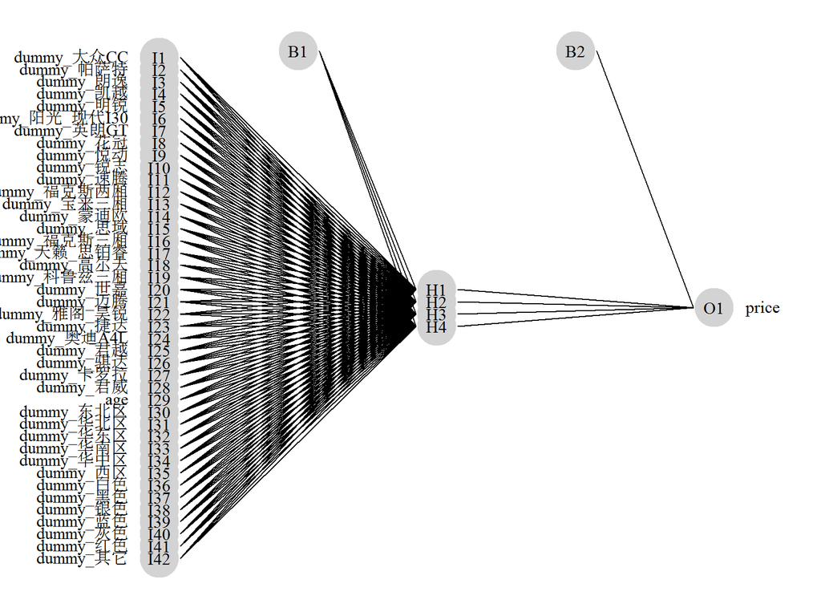

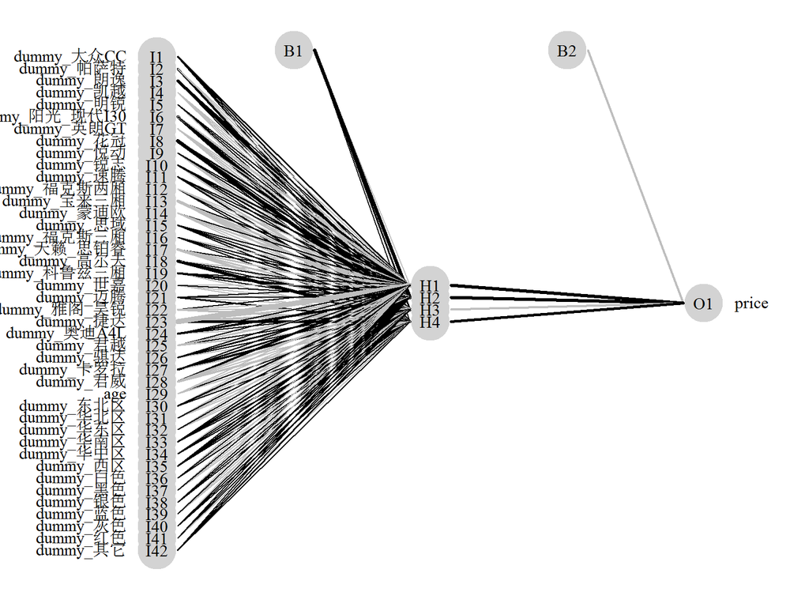

训练数据集MRSE 0.0731581

验证数据集MRSE 0.0726492

优信拍数据集MRSE 0.0774651  
如何从神经网络中提取公式

根据神经网络的topology，总结出公式如下

```
## a 7-1-1 network with 10 weights
## options were - decay=0.01
##  b->h1 i1->h1 i2->h1 i3->h1 i4->h1 i5->h1 i6->h1 i7->h1
##  -1.19   1.84   0.14  -0.02   0.16   0.07   0.69  -2.65
##  b->o h1->o
## -2.99 12.48
```

$h1<-(-1.1895594+ 1.841839* x\_model +0.1400066* x\_color +-0.0185628*x\_gtcl + 0.1635625* x\_ctlx + 0.0736848*x\_jqfs+ 0.6861709*x\_province + -2.6491495* x\_level )$ $a1<- 1/(1+exp(-h1))$ $o1 <- ( -2.988866+12.4801263*a1)$ $outpred<- 1/(1+exp(-o1))$